# Automating everything: we should always strive for it!

Jorge Cimentada  
9th of March 2017

### Functions in R

This is a function.

```r
adds_1 <- function(my_number) {
  my_number + 1
}

adds_1(5)
```

```
[1] 6
```

- You need to pick a *name* for the function
- You list the inputs or *arguments* inside the blue function
- You place the code you have developed in the *body* of the function

#### When should you write a function?

Write a function whenever you’ve copied and pasted a block of code more than twice.

### Functions in R

Functions can be used within other functions:

```r
multiplier <- function(x, number) {
  adds_1(x) * number
}

multiplier(5, 2)
```

What is the result of this function call?

### Functions in R

You can think of functions like little factories: Every factory takes some inputs, and returns an output (its product).

- They take some inputs (function arguments) and return an output.
- They are black boxes. From the outside, nobody knows what goes on inside the factory.

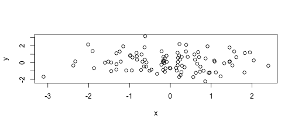

```r
random_num_generator <- function(n) {
  x <- rnorm(n)
  y <- rnorm(n)
  plot(x, y)
}

random_num_generator(100)
```

Run this and try searching for `x` or `y` inside your working directory.

### Functions in R

Everytime you call a function, everything that is created inside the function belongs to that functions environment.

Our GlobalEnvironment

```r
environment()
```

```
<environment: R_GlobalEnv>
```

The environment inside a function (randomly generated)

```r
function_env <- function() environment()
function_env()
```

```
<environment: 0x7fb2e9ae8400>
```

## Think of environments as boxes that contain objects such as functions and vectors. Inside a function, this box is created when the function runs and deleted when the function ends.

### Functions in R

Let's create a function that calculates the variance of a vector x:

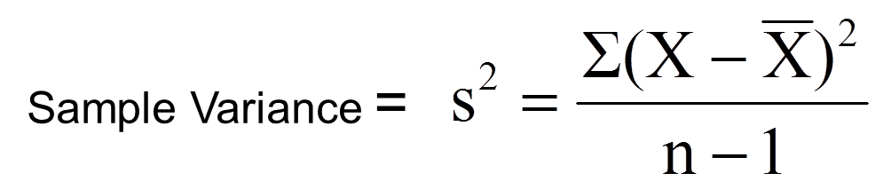

Clearly there are three steps to calculating this formula:

- Calculate the deviance
- Correct the sample size to make the estimator unbiased
- Divide the deviance by the corrected sample size

### Functions in R

- Create a vector called `x` which has `rnorm(100)` inside. With this we'll generate `100` random numbers with a normal distribution.
- Find the mean of the vector x with `mean(x)`
- Let's subtract each `x` from the `mean(x)`. This will give us the deviations from the overall mean.
- How can we subtract a single number from every element of a vector?

### Functions in R

### Answer:

```r
set.seed(1)

x <- rnorm(100)
mu <- mean(x)
x - mu
```

```
  [1] -0.73534118  0.07475596 -0.94451598  1.48639344  0.22062040
  [6] -0.92935575  0.37854169  0.62943734  0.46689398 -0.41427575
 [11]  1.40289380  0.28095587 -0.73012795 -2.32358725  1.01604355
 [16] -0.15382098 -0.12507763  0.83494884  0.71233383  0.48501395
 [21]  0.81009000  0.67324893 -0.03432238 -2.09823906  0.51093838
 [26] -0.16501611 -0.26468287 -1.57963975 -0.58703742  0.30905419
 [31]  1.24979218 -0.21167509  0.27878424 -0.16269241 -1.48594692
 [36] -0.52388193 -0.50317732 -0.16820076  0.99113801  0.65428838
 [41] -0.27341096 -0.36224905  0.58807601  0.44777583 -0.79764306
 [46] -0.81638252  0.25569460  0.65964556 -0.22123358  0.77222036
 [51]  0.28921851 -0.72091376  0.23223232 -1.23825046  1.32413633
 [56]  1.87151253 -0.47610884 -1.15302199  0.46083226 -0.24394197
 [61]  2.29273039 -0.14812737  0.58085200 -0.08088521 -0.85216058
 [66]  0.07990493 -1.91384600  1.35666749  0.04436597  2.06372430
 [71]  0.36662216 -0.81883380  0.50183899 -1.04298500 -1.36252077
 [76]  0.18255887 -0.55217924 -0.10778202 -0.03454604 -0.69840831
 [81] -0.67755610 -0.24406598  1.06919963 -1.63245417  0.48505882
 [86]  0.22406300  0.95421247 -0.41307129  0.26113144  0.15821142
 [91] -0.65140740  1.09898044  1.05151525  0.59132628  1.47794609
 [96]  0.44959906 -1.38547958 -0.68215278 -1.33349998 -0.58228800
```

- What does `x - mu` give us? A scalar or a vector?
- How can we square every element of a vector?
- How can we sum the elements of a vector?

### Functions in R

Understanding the “environments” from before is key to writing code with fewer bugs: the simpler the environment, the fewer things can go wrong.

Let's create a simple function with a simple environment that calculates the deviance:

```r
deviance_sq <- function (x) {
    mu <- mean(x) # create an intermediate variable `mu`
    sum((x - mu)^2) # use mu to calculate the deviance
}
```

- The inputs are called arguments. In this case we take one (x).
- The output is called the “return value”. R will return the value of the last line of the function.
- Here the environment of our functions has two variables, the input “x”, and an intermediate value “mu”.

### Functions in R

Simpler environments have fewer intermediate variables. Maybe we can try removing one intermediate variable to make the environment inside our function simpler:

```r
mu <- mean(x)
deviance_sq <- function (x) {
    sum((x - mu)^2)
}
```

What is happening here???

- The function body demands a variable `mu`. R will first search for `mu` inside the functions environment.
- If it doesn't find it there, it will look for the function in the next environment *higher* up.
- Did we improve our code?

### Functions in R

```r
deviance_sq(c(1,2,3))
```

```
[1] 12.72892
```

```r
mu <- 2000

deviance_sq(c(1,2,3))
```

```
[1] 11976014
```

We can no longer rely on deviance_sq to give the correct deviance to our data!

- Functions which only demand variables from their own environment (only rely on their inputs) are called *pure* functions.
- Tidyverse functions are almost always pure!
- We want our functions to have simple environments, but we also want them to be pure.

### Functions in R

We know how functions look up variables, but how do functions look up other functions?

**Exactly the same way**

```r
set.seed(1)

our_plot <- function(x, y) plot(x, y)

random_num_generator <- function() {
  x <- rnorm(100)
  y <- rnorm(100)
  our_plot(x, y)
}
```

It will search the environment of the function and look for `our_plot` and `rnorm`, if not found, it will look in the *parent environment* and so on..

### Functions in R

This too can be dangerous:

```r
deviance_sq <- function (x) {
    mu <- mean(x)
    sum((x - mu)^2)
}
deviance_sq(c(1,2,3))
```

```
[1] 2
```

```r
mean <- function (y) {
     y*5000000
}
deviance_sq(c(1,2,3))
```

```
[1] 3.499999e+14
```

- We admit that most of our functions will rely on other functions.
- We need to be careful when choosing function names!

### Functions in R

Before keeping going, remember to `rm(mean)`

Like most things we do, calculating the variance involves multiple steps. Each step is full of opportunities for bugs. If we create a pure function for every step, we can test each step, and rely on each step working.

Let's write our steps in comments.

```r
our_variance <- function(x) {
    # Calculate the deviance
    # Correct the sample size to make the estimator unbiased
    # Divide the deviance by the corrected sample size
}
```

### Functions in R

We already created a a function to calculate the deviance, so let's create a function that gives us the corrected sample size:

```r
unbiased_size <- function(x) length(x) - 1
```

- Notice we can ommit the `{}` if the function is only one line!

Let's test this to make sure we get what we expect:

```r
unbiased_size(c(1,2,3,4,5))
```

```
[1] 4
```

```r
unbiased_size(c(1))
```

```
[1] 0
```

- Is the last example going to cause a problem for us???

### Functions in R

Clearly we can't have our unbiased size function return 0's. Let's make the function return a minimum of 1, always. How can we do that?

- We learned that a function returns the last line.
- We can use `return()` to return a value from the middle of the function!
- This allows us to create a function that returns different things based on the input:

```r
unbiased_size <- function(x) {
  if (length(x) <= 1) {
    return(1)
  }
  length(x) - 1
}
```

```r
unbiased_size(c(1,2))
unbiased_size(c(1))
```

Without running the function, predict the result of both calls..

### Functions in R

Great! Now we have a function to compute deviance and one to correct the size of our sample. Let's see what we have left:

```r
our_variance <- function(x) {
    # Divide the deviance by the corrected sample size
}
```

- We need a function that divides a number by another number.
- We don't need to create this ourselves because R already has it!
- You finish `our_variance` function by dividing `deviance_sq()` over `unbiased_size()`.
- Remember we will only use one argument.

### Functions in R

### Answer:

```r
our_variance <- function (x) deviance_sq(x) / unbiased_size(x)
```

Let's confirm that our results are correct:

```r
c(our_result = our_variance(x), R_result = var(x))
```

```
our_result   R_result
 0.8067621  0.8067621
```

### Functions in R

Congrats! That's your first function, if you hadn't created one.

Now, this is the formula for the standard deviation:

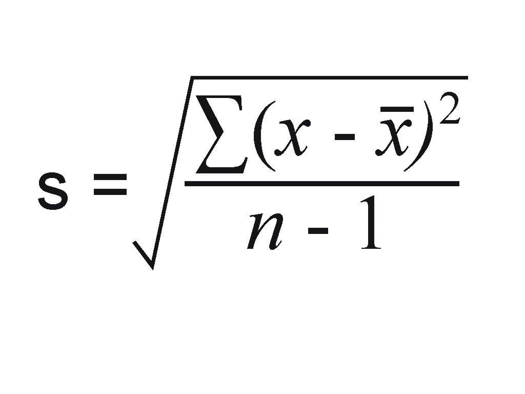

## Comparing this to the variance formula, how is this different?

### Functions in R

Let's implement it ourself. Remember that `our_variance` already calculates the variance so we simply need to…

- Wrap `our_variance` with the `sqrt()` function
- Wrap that in a function called `our_sd` and
- Remember that this new function will only accept one argument, `x`, which is gonna be passed to `our_variance`.

### Functions in R

This is the correct answer:

```r
our_sd <- function(x) {
  sqrt(our_variance(x))
}
```

Let's explain how this works:

- `our_sd` first searches for `our_variance` inside the function body and once it doesn't find it, it searches in the global environment and finds it.
- `x` is passed to `our_variance`, the function returns the variance, and then `sqrt` simply takes the square root of the result of `our_variance`.

### Functions in R

Remember the “pipe” operator we used with dplyr?

```r
library(dplyr)
our_sd <- function(x) {
  our_variance(x) %>% sqrt()
}
```

It works with our functions too! We can create an assembly line of small functions and pipe them into each other. We can test each function individually, and have a system that works reliably.

Let's test our new standard deviation function!

### Functions in R

```r
set.seed(1)
x <- rnorm(10^7)
our_sd(x); sd(x)
```

```
[1] 1.000231
```

```
[1] 1.000231
```

Same result. What about performance time?

```r
system.time(our_sd(x)); system.time(sd(x))
```

```
   user  system elapsed
  0.067   0.005   0.072
```

```
   user  system elapsed
  0.044   0.001   0.045
```

### Functions in R

Most basic R functions are implement in C++ for faster performance.

- It's better to leave base functions as they are.
- This example is simply to show you how to create functions!

### Functions in R

Let's extend the standard deviation to create a function that calculates confidence intervals.

I won't bore you with the statistics so I'll give you the confidence intervals estimation.

```r
x <- rnorm(10^5, mean = 5, sd = 5) # Our variable of interest
ci_level <- 0.95 # Our confidence interval

# Z value calculation
a <- (1 - ci_level) / 2
z_value <- qnorm(1 - a)

# Confidence interval calcuation
lower_ci <- mean(x) -  (z_value * our_sd(x)) # We use our_sd function which uses our_variance. How cool!
upper_ci <- mean(x) +  (z_value * our_sd(x))
```

Now, you complete the work:

- Create a function with the name `our_ci`.
- This function will have two arguments, one called `x`, and another one called `ci_level` which will have the number `0.95` by default.
- Paste the code from above inside the function excluding the `x` and ci_level vectors.

### Functions in R

### Answer:

```r
our_ci <- function(x, ci_level = 0.95) {

  # Z value calculation
  a <- (1 - ci_level) / 2
  z_value <- qnorm(1 - a)

  # Confidence interval calcuation
  lower_ci <- mean(x) -  (z_value * our_sd(x)) # See using our_sd function which uses our_variance
  upper_ci <- mean(x) +  (z_value * our_sd(x))
}
```

- Using the `c()` function concatenate `lower_ci` and `upper_ci` and paste it as the last line of the function.
- We wanna make sure the output of our function are the lower and upper bounds in that order.

### Functions in R

### Answer:

```r
our_ci <- function(x, ci_level = 0.95) {
  # Z value calculation
  a <- (1 - ci_level) / 2
  z_value <- qnorm(1 - a)
  # Confidence interval calcuation
  lower_ci <- mean(x) -  (z_value * our_sd(x)) # See using our_sd function which uses our_variance
  upper_ci <- mean(x) +  (z_value * our_sd(x))

  c(lower_bound = lower_ci, upper_bound = upper_ci)
}
```

### Functions in R

Let's test whether our function returns what we want:

```r
age <- rnorm(10^5, mean = 10, sd = 2)

our_ci(age, ci_level = 0.95)
```

```
lower_bound upper_bound
   6.077545   13.907102
```

```r
our_ci(age, ci_level = 0.80)
```

```
lower_bound upper_bound
   7.432588   12.552060
```

```r
our_ci(age, ci_level = 0.50)
```

```
lower_bound upper_bound
   8.645116   11.339531
```

### Loops, apply family and purrr package.

Loops are tools we can use to repeat code N times.

For example:

```r
for (i in 1:5) {
  print(i)
}
```

```
[1] 1
[1] 2
[1] 3
[1] 4
[1] 5
```

- In the first run, `i == 1` because `1` is first number of `1:5`. In the second run `i == 2`, and so on.
- If the sequence would've been `2`, `4` and `6`, then in the first run `i == 2`, runs everything and then starts again with `i == 4` and so on.

### Loops, apply family and purrr package.

- You can also *not* use the `i` to simply repeat the same thing N times.

For example:

```r
for (i in 1:5) {
  print("Hey")
}
```

```
[1] "Hey"
[1] "Hey"
[1] "Hey"
[1] "Hey"
[1] "Hey"
```

### Loops, apply family and purrr package.

And most commonly, in R, you can use the `i` to *subset* numbers from vectors. *This loop you will write yourself.*

We want to create a loop that calculates the confidence interval of our `x` variable for several `ci_values` without having to rewrite the same expression several times.

- Create a vector called `ci_values` which has this sequence of numbers: `seq(0.50, 0.90, 0.10)`. (Check its contents)
- How long is `ci_values`? Calculate its length with `length()` and save it to the name `n`.
- Create an empty *loop* skeleton based on the previous one

### Loops, apply family and purrr package.

#### Answer:

```r
ci_values <- seq(0.50, 0.90, 0.10)
n <- length(ci_values)

for () {

}
```

- We want to loop through the values in `ci_values` so we need to have a sequence of numbers of `1:length(ci_values)`. This will make sure to index EACH value of the ci_values.
- Inside the parenthesis make sure `i` loops through `1:n`. Have a look at the previous loop if you forgot the syntax!
- Using the `our_ci` function, calculate the confidence interval for x
- In the `ci_level` *argument* (second argument of the function) specify `ci_values[i]`.

### Loops, apply family and purrr package.

```r
ci_values <- seq(0.50, 0.90, 0.10)
n <- length(ci_values)

for (i in 1:n) {
  print(our_ci(x, ci_level = ci_values[i]))
}
```

What is happening here?

- The loop will run the first time where `i == 1` and will pick `ci_values[1]`, so the first confidence interval will be for `0.50`.
- In the second iteration `i == 2`, so the same loop will be repeated. But with one difference: `ci_values[2]`. This means that the second uncertainty interval will be for `0.60`.
- This procedure gets repeated until `i` iterates over each number in `1:n`.

### Loops, apply family and purrr package.

## Result:

```r
ci_values <- seq(0.50, 0.90, 0.10)
n <- length(ci_values)

for (i in 1:n) {
  print(our_ci(x, ci_level = ci_values[i]))
}
```

```
lower_bound upper_bound
   1.610718    8.377848
lower_bound upper_bound
  0.7723062   9.2162600
lower_bound upper_bound
 -0.2049653  10.1935315
lower_bound upper_bound
  -1.434596   11.423162
lower_bound upper_bound
  -3.257094   13.245660
```

### Loops, apply family and purrr package.

Loops are concepts from computer science that are widespread across all programming languages.

But in R, they're usually not advised unless in specific situations:

- The main reason is that loops tend to be slow (see [here](http://stackoverflow.com/questions/7142767/why-are-loops-slow-in-r) for an explanation why loops are slow and a counter-explanation from Karl Broman with an article showing that loops are ideal in some situations)

For that reason, R users have developed the `apply` family and the tidyverse has the `purrr` package.

### Loops, apply family and purrr package.

In short, the apply functions are loops but they're expressed in a different way.

Look at this example:

```r
x <- 1:10

# This function accepts a vector and returns the same vector + 1
adder <- function(our_vec) {
  our_vec + 1
}

sapply(x, adder)
```

Try to visualize it this way:

```
adder + 1 adder + 1 adder + 1 adder + 1 adder + 1 adder + 1
        1         2         3         4         5         6
```

- The `sapply` function takes the first object of the vector and applies the function.
- Then takes the second argument and repeats the same thing.

### Loops, apply family and purrr package.

Behind the scenes, this is exactly what's happening:

```r
x <- 1:10

sapply(x, adder) # is equal to
adder(x[1])
adder(x[2])
adder(x[3])
...
adder(x[N])
```

So `sapply` passes the first argument of `sapply` to the argument of the `adder` function.

### Loops, apply family and purrr package.

The apply family of functions(`sapply`, `lapply`, `apply`, `vapply`, `tapply`, etc..) work VERY similarly, so if you understand how one works you can undestand how most work.

For example, `sapply` is the same as `lapply` but `lapply` ONLY returns a list.

Our previous example:

```r
sapply(x, adder)
```

```
 [1]  2  3  4  5  6  7  8  9 10 11
```

```r
lapply(x, adder)[1:2]
```

```
[[1]]
[1] 2

[[2]]
[1] 3
```

### Loops, apply family and purrr package.

Don't get stuck up on simply moving values into a functions arguments.

```r
descriptives <- list(mean, median, our_sd, our_variance, our_ci)
sapply(descriptives, function(our_fun) our_fun(x))
```

The function on the right is called an `anonymous function`. This means that the function is created on the spot (it doesn't have a name).

This code might look daunting but we're effectively doing the same thing:

- Take the first object of `descriptives` and pass it as the first argument of the `anonymous function`
- The first argument in the function is named `our_fun` and this argument then wraps `x` (which is our vector of interest)
- So the first run of the loop will take the function `mean` and calculate `mean(x)`
- The second run of the loop will take the function `median` and calculate `median(x)`
- And so on.. until the end of the list `descriptives`

## Why is the output of sapply a list?

### Loops, apply family and purrr package.

If you understand the `apply` functions, `purrr` is even easier because all functions workly similarly.

`purrr` is a rewrite of the `apply` family but with more consistency. Every looping function in `purrr` is called `map` instad of `apply`:

```r
map(.x, .f, ...) # Always returns a list
map_lgl(.x, .f, ...) # Always returns a logical
map_chr(.x, .f, ...) # Always returns a character
map_int(.x, .f, ...) # Always returns a integer
map_dbl(.x, .f, ...) # Always returns a double
map_df(.x, .f, ..., .id = NULL) # Always returns a data frame
```

`.x` is always the value and `.f` is always the function (this order is not the same in the `apply` functions, see `?sapply` and `?mapply`).

All `map` variants make the sure the result is of the class `lgl`, `chr`, etc.. (remember how `sapply` gave us a list?)

### Loops, apply family and purrr package.

Enough of the theoretical talk, let's get your hands dirty.

Let's use the PISA data.

```r
library(tidyverse)
url <- "https://raw.githubusercontent.com/cimentadaj/tidyverse_seminars/master/first_seminar/data/pisa2015.csv"
student <- read_csv(url) %>%
  filter(!is.na(FISCED))
student
```

```
# A tibble: 9,302 × 921
   CNTRYID                  CNT CNTSCHID CNTSTUID   CYC NatCen   Region
     <int>                <chr>    <dbl>    <dbl> <chr>  <chr>    <chr>
1      780  Trinidad and Tobago 78000022 78001092  06MS 078000 Americas
2      784 United Arab Emirates 78400393 78412661  06MS 078400     Asia
3      442           Luxembourg 44200016 44201761  06MS 044200   Europe
4      792               Turkey 79200019 79201420  06MS 079200     Asia
5      428               Latvia 42800134 42802282  06MS 042800   Europe
6       76               Brazil  7600667  7622701  06MS 007600 Americas
7      246              Finland 24600112 24604748  06MS 024600   Europe
8      788              Tunisia 78800105 78801159  06MS 078800   Africa
9      643   Russian Federation 64300108 64304364  06MS 064300   Europe
10     203       Czech Republic 20300280 20302661  06MS 020300   Europe
# ... with 9,292 more rows, and 914 more variables: STRATUM <chr>,
#   SUBNATIO <chr>, OECD <int>, ADMINMODE <int>, Option_CPS <int>,
#   Option_FL <int>, Option_ICTQ <int>, Option_ECQ <int>, Option_PQ <int>,
#   Option_TQ <int>, Option_UH <int>, Option_Read <chr>,
#   Option_Math <chr>, LANGTEST_QQQ <dbl>, LANGTEST_COG <int>,
#   LANGTEST_PAQ <dbl>, CBASCI <dbl>, BOOKID <int>, ST001D01T <int>,
#   ST003D02T <int>, ST003D03T <int>, ST004D01T <int>, ST005Q01TA <dbl>,
#   ST006Q01TA <dbl>, ST006Q02TA <dbl>, ST006Q03TA <dbl>,
#   ST006Q04TA <dbl>, ST007Q01TA <dbl>, ST008Q01TA <dbl>,
#   ST008Q02TA <dbl>, ST008Q03TA <dbl>, ST008Q04TA <dbl>,
#   ST011Q01TA <dbl>, ST011Q02TA <dbl>, ST011Q03TA <dbl>,
#   ST011Q04TA <dbl>, ST011Q05TA <dbl>, ST011Q06TA <dbl>,
#   ST011Q07TA <dbl>, ST011Q08TA <dbl>, ST011Q09TA <dbl>,
#   ST011Q10TA <dbl>, ST011Q11TA <dbl>, ST011Q12TA <dbl>,
#   ST011Q16NA <dbl>, ST011D17TA <chr>, ST011D18TA <chr>,
#   ST011D19TA <chr>, ST012Q01TA <dbl>, ST012Q02TA <dbl>,
#   ST012Q03TA <dbl>, ST012Q05NA <dbl>, ST012Q06NA <dbl>,
#   ST012Q07NA <dbl>, ST012Q08NA <dbl>, ST012Q09NA <dbl>,
#   ST013Q01TA <dbl>, ST123Q01NA <dbl>, ST123Q02NA <dbl>,
#   ST123Q03NA <dbl>, ST123Q04NA <dbl>, ST019AQ01T <dbl>,
#   ST019BQ01T <dbl>, ST019CQ01T <dbl>, ST021Q01TA <dbl>,
#   ST022Q01TA <dbl>, ST124Q01TA <dbl>, ST125Q01NA <dbl>,
#   ST126Q01TA <dbl>, ST127Q01TA <dbl>, ST127Q02TA <dbl>,
#   ST127Q03TA <dbl>, ST111Q01TA <dbl>, ST118Q01NA <dbl>,
#   ST118Q02NA <dbl>, ST118Q03NA <dbl>, ST118Q04NA <dbl>,
#   ST118Q05NA <dbl>, ST119Q01NA <dbl>, ST119Q02NA <dbl>,
#   ST119Q03NA <dbl>, ST119Q04NA <dbl>, ST119Q05NA <dbl>,
#   ST121Q01NA <dbl>, ST121Q02NA <dbl>, ST121Q03NA <dbl>,
#   ST082Q01NA <dbl>, ST082Q02NA <dbl>, ST082Q03NA <dbl>,
#   ST082Q08NA <dbl>, ST082Q09NA <dbl>, ST082Q12NA <dbl>,
#   ST082Q13NA <dbl>, ST082Q14NA <dbl>, ST034Q01TA <dbl>,
#   ST034Q02TA <dbl>, ST034Q03TA <dbl>, ST034Q04TA <dbl>,
#   ST034Q05TA <dbl>, ST034Q06TA <dbl>, ...
```

### Loops, apply family and purrr package.

Briefly, `nest` is a function that turns chunks of data frames into lists.

```r
(student_nested <-
  student %>%
  group_by(CNT) %>%
  nest()) %>%
  head(8)
```

```
# A tibble: 8 × 2
                   CNT                 data
                 <chr>               <list>
1  Trinidad and Tobago  <tibble [84 × 920]>
2 United Arab Emirates <tibble [270 × 920]>
3           Luxembourg  <tibble [95 × 920]>
4               Turkey  <tibble [98 × 920]>
5               Latvia  <tibble [93 × 920]>
6               Brazil <tibble [406 × 920]>
7              Finland <tibble [119 × 920]>
8              Tunisia  <tibble [92 × 920]>
```

This is VERY powerful.. look at the simpleness of this `tibble`.

### Loops, apply family and purrr package.

Each country `tibble` has `920` columns all in upper case. First, let's turn all the columns into `lowercase`.

- The `data` column is a list, so we can `map` through that list, change the column names to lower case and return the new data frame
- We will obtain a list containing each tibble with the lowercase column names and replace the existing `data` column.

```r
student_nested %>%
  mutate(data = map(data, function(country_tibble) {
    names(country_tibble) <- tolower(names(country_tibble))
    country_tibble
}))
```

```
# A tibble: 69 × 2
                    CNT                 data
                  <chr>               <list>
1   Trinidad and Tobago  <tibble [84 × 920]>
2  United Arab Emirates <tibble [270 × 920]>
3            Luxembourg  <tibble [95 × 920]>
4                Turkey  <tibble [98 × 920]>
5                Latvia  <tibble [93 × 920]>
6                Brazil <tibble [406 × 920]>
7               Finland <tibble [119 × 920]>
8               Tunisia  <tibble [92 × 920]>
9    Russian Federation <tibble [125 × 920]>
10       Czech Republic <tibble [126 × 920]>
# ... with 59 more rows
```

### Loops, apply family and purrr package.

Wait! What did you just do?

- Remember `data` is a list containing a tibble for each country, so loop through each of these.
- `country_tibble` is just the name of the only argument of our `anonymous function`.
- The `anonymous function` changes the names of the tibble and then returns the tibble.
- So in each loop we will change the column names and then return the updated column.

```r
map(data, function(country_tibble) {
    names(country_tibble) <- tolower(names(country_tibble))
    country_tibble
})
```

Because this will return a *list* with each object being a tibble, we simply replaced the `data` column with this updated lowercase name tibble!

See? Once we understand it, it makes sense.

### Loops, apply family and purrr package.

Copy the previous code that has the `mutate` function and inside our `anonymous function` (remember, the function created on the spot that doesn't have a name) …

- pipe the last line to `rename` and change the name of the variables to `math`, `father_edu` and `gender`. Remember, the new name comes *before* the `=` sign
- pipe the result to `select` and pick the three variables

### Loops, apply family and purrr package.

#### Answer:

```r
(student_nested <-
  student_nested %>%
  mutate(data = map(data, function(country_tibble) {
    names(country_tibble) <- tolower(names(country_tibble))

    country_tibble %>%
      rename(math = pv1math, father_edu = misced, gender = st004d01t) %>%
      select(math, father_edu, gender)
}))) %>%
  head(6)
```

```
# A tibble: 6 × 2
                   CNT               data
                 <chr>             <list>
1  Trinidad and Tobago  <tibble [84 × 3]>
2 United Arab Emirates <tibble [270 × 3]>
3           Luxembourg  <tibble [95 × 3]>
4               Turkey  <tibble [98 × 3]>
5               Latvia  <tibble [93 × 3]>
6               Brazil <tibble [406 × 3]>
```

### Loops, apply family and purrr package.

Look at how clean our tibble is. One single data frame encapsulating all the changes.

Once we're here we can do really cool stuff with the `map` family. How could we calculate the mean `math` score for each country?

Without saving anything:

- Pipe `student_nested$data` to `map_dbl` (why `map_dbl`?) and create an `anonymous function` that has one argument called `country_data`.
- Open `{}` brackets and inside the function calculcate the `mean` of `country_data$math`. Remember to exclude `NA's` by typing `na.rm = T`.

### Loops, apply family and purrr package.

### Answer:

```r
student_nested$data %>%
  map_dbl(function(country_data) mean(country_data$math, na.rm = T))
```

```
 [1] 410.8914 429.1818 486.0579 414.0818 487.9166 374.2518 504.5360
 [8] 356.6824 497.7577 511.8730 394.8838 508.8593 498.5570 542.7722
[15] 497.5995 497.6205 446.4907 482.4520 546.0608 481.7194 433.0041
[22] 480.0614 514.0620 514.6431 452.5950 517.7064 429.0508 526.7513
[29] 552.1916 442.4864 405.9293 472.6949 365.7731 523.9632 458.9535
[36] 495.8390 359.2941 405.4707 383.9953 524.7178 541.2049 467.5123
[43] 420.6538 433.5105 515.4992 494.1536 502.0734 404.1077 494.4110
[50] 373.0315 509.2964 486.6501 511.4588 507.6009 496.6202 508.2001
[57] 391.6478 399.1047 513.7178 466.8586 546.7874 543.5644 400.9513
[64] 498.9575 486.9804 440.7252 471.0188 363.6423 323.0348
```

Those are the means of each specific country but we can't tease out which belongs to which.

### Loops, apply family and purrr package.

Let's turn the previous result into a column of `student_nested`.

- Pipe `student_nested` to `mutate` and create a new variable called `mean_math`.
- Inside `mean_math` specify `map_dbl` as the function and the column `data` as the first argument of `map_dbl`.
- Finally, copy the `anonymous function` from before as the function argument of `map_dbl`.

### Loops, apply family and purrr package.

```r
student_nested %>%
  mutate(mean_math = map_dbl(data, function(country_data) mean(country_data$math, na.rm = T)))
```

```
# A tibble: 69 × 3
                    CNT               data mean_math
                  <chr>             <list>     <dbl>
1   Trinidad and Tobago  <tibble [84 × 3]>  410.8914
2  United Arab Emirates <tibble [270 × 3]>  429.1818
3            Luxembourg  <tibble [95 × 3]>  486.0579
4                Turkey  <tibble [98 × 3]>  414.0818
5                Latvia  <tibble [93 × 3]>  487.9166
6                Brazil <tibble [406 × 3]>  374.2518
7               Finland <tibble [119 × 3]>  504.5360
8               Tunisia  <tibble [92 × 3]>  356.6824
9    Russian Federation <tibble [125 × 3]>  497.7577
10       Czech Republic <tibble [126 × 3]>  511.8730
# ... with 59 more rows
```

We could use our function `our_ci` to create two additional columns containing the upper and lower bounds of that mean.

### Loops, apply family and purrr package.

Let's do that.

- Create two new columns (with the same structure as the `mean_math` column) one named `lower_bound` and the other named `upper_bound`.
- In both columns you'll simply use `our_ci` instead of `mean` function.
- But remember that the output of `our_ci` are two numbers (first lower then upper bounds), so for the `lower_bound` variable you'll need to run the same thing but subset the first object;
- For the upper variable you'll need to run exactly the same thing but subset the second object.

### Loops, apply family and purrr package.

### Answer:

```r
student_nested %>%
  mutate(mean_math = map_dbl(data, function(country_data) mean(country_data$math, na.rm = T)),
         lower_bound = map_dbl(data, function(country_data) our_ci(country_data$math)[1]),
         upper_bound = map_dbl(data, function(country_data) our_ci(country_data$math)[2]))
```

```
# A tibble: 69 × 5
                    CNT               data mean_math lower_bound
                  <chr>             <list>     <dbl>       <dbl>
1   Trinidad and Tobago  <tibble [84 × 3]>  410.8914    208.9468
2  United Arab Emirates <tibble [270 × 3]>  429.1818    229.3306
3            Luxembourg  <tibble [95 × 3]>  486.0579    298.5919
4                Turkey  <tibble [98 × 3]>  414.0818    258.5891
5                Latvia  <tibble [93 × 3]>  487.9166    341.5515
6                Brazil <tibble [406 × 3]>  374.2518    203.1531
7               Finland <tibble [119 × 3]>  504.5360    350.6053
8               Tunisia  <tibble [92 × 3]>  356.6824    184.9170
9    Russian Federation <tibble [125 × 3]>  497.7577    337.0385
10       Czech Republic <tibble [126 × 3]>  511.8730    335.5443
# ... with 59 more rows, and 1 more variables: upper_bound <dbl>
```

Alright, let's start to wrap things up. Let's talk about how to incorporate statistical modeling together with the `tidyverse`.

### Loops, apply family and purrr package.

The function to compute linear modeling in R is `lm`.

Think about this code:

```r
student_nested %>%
  mutate(lm_model = map(data, function(country_data) lm(math ~ father_edu + gender, data=country_data)))
```

```
# A tibble: 69 × 3
                    CNT               data lm_model
                  <chr>             <list>   <list>
1   Trinidad and Tobago  <tibble [84 × 3]> <S3: lm>
2  United Arab Emirates <tibble [270 × 3]> <S3: lm>
3            Luxembourg  <tibble [95 × 3]> <S3: lm>
4                Turkey  <tibble [98 × 3]> <S3: lm>
5                Latvia  <tibble [93 × 3]> <S3: lm>
6                Brazil <tibble [406 × 3]> <S3: lm>
7               Finland <tibble [119 × 3]> <S3: lm>
8               Tunisia  <tibble [92 × 3]> <S3: lm>
9    Russian Federation <tibble [125 × 3]> <S3: lm>
10       Czech Republic <tibble [126 × 3]> <S3: lm>
# ... with 59 more rows
```

Try to understand it:

- I'm looping through each dataset and calculating a linear model
- The output will be a list, so we save it with a name `lm_model`

### Loops, apply family and purrr package.

```
[[1]]

Call:
lm(formula = math ~ father_edu + gender, data = country_data)

Coefficients:
(Intercept)   father_edu       gender
     394.02        15.53       -25.60
```

This is the result of a linear model with the `intercept` and `coefficients` of both variables. This is useful for interpretation but not for data manipulation.

For turning modeling outputs into `tidy` tibbles we can use the `tidy` function from the `broom` package.

### Loops, apply family and purrr package.

```r
library(broom)

(student_lm <-
  student_nested %>%
  mutate(lm = map(data, function(country_data)
    tidy(lm(math ~ father_edu + gender, data=country_data))))) %>%
  head(5)
```

```
# A tibble: 5 × 3
                   CNT               data                   lm
                 <chr>             <list>               <list>
1  Trinidad and Tobago  <tibble [84 × 3]> <data.frame [3 × 5]>
2 United Arab Emirates <tibble [270 × 3]> <data.frame [3 × 5]>
3           Luxembourg  <tibble [95 × 3]> <data.frame [3 × 5]>
4               Turkey  <tibble [98 × 3]> <data.frame [3 × 5]>
5               Latvia  <tibble [93 × 3]> <data.frame [3 × 5]>
```

Don't feel intimidated by all this code. We're doing the same thing as before but wrapping each `lm` output with `tidy`. `tidy` turns that into a data frame.

Now we have a data frame of the regression output for each country!

### Loops, apply family and purrr package.

To finish, we `unnest` the `lm` column to compare slopes.

```r
(student_lm <-
  student_lm %>%
  unnest(lm))
```

```
# A tibble: 207 × 6
                    CNT        term   estimate std.error statistic
                  <chr>       <chr>      <dbl>     <dbl>     <dbl>
1   Trinidad and Tobago (Intercept) 394.015422 42.600657  9.249046
2   Trinidad and Tobago  father_edu  15.532577  6.297611  2.466424
3   Trinidad and Tobago      gender -25.597254 22.427857 -1.141315
4  United Arab Emirates (Intercept) 373.096271 26.752898 13.946013
5  United Arab Emirates  father_edu  11.032378  3.896668  2.831234
6  United Arab Emirates      gender   2.425185 12.341152  0.196512
7            Luxembourg (Intercept) 408.709193 40.838981 10.007821
8            Luxembourg  father_edu   6.907076  5.269616  1.310736
9            Luxembourg      gender  31.916418 20.917358  1.525834
10               Turkey (Intercept) 411.335247 26.489628 15.528162
# ... with 197 more rows, and 1 more variables: p.value <dbl>
```

### Loops, apply family and purrr package.

We could graph that by filtering the specific slope:

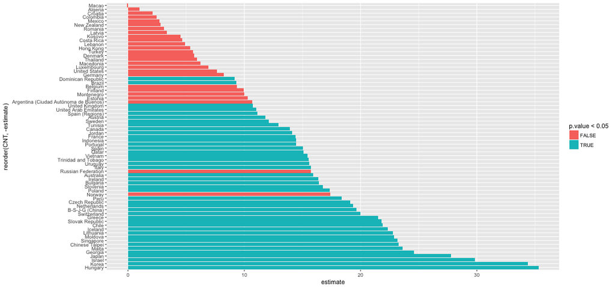

```r
student_lm %>%
  filter(term == "father_edu") %>%
  ggplot(aes(reorder(CNT, -estimate), estimate, fill = p.value < 0.05)) +
  geom_col() +
  coord_flip()
```

### Loops, apply family and purrr package.

Or we could graph the slope as a line instead of a plot:

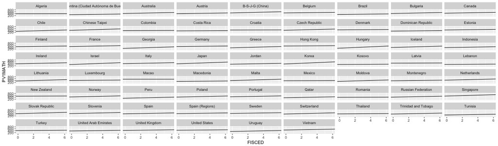

```r
slope_students <-
  student_lm %>%
  filter(term != "gender") %>%
  select(CNT, term, estimate) %>%
  spread(term, estimate)

ggplot(student, aes(x = FISCED, y = PV1MATH)) +
  geom_point(alpha = 0.0000) +
  geom_abline(data = slope_students, aes(intercept = `(Intercept)`, slope = father_edu)) +
  facet_wrap(~ CNT)
```

### Conclusions.

Some pointers:

- Everytime you write a code more than two or three times, think about how to turn it into a function
- Functions are not only for statistical analysis but for ANYTHING you can think of automating(data wrangling, plots, custom made calculations)
- Whenever you're repeating a function many times (and only changing one thing), considering using the `map` family
- The benefits are obvious: less code, more readable and more compact
- Write, write and write functions and loops (either `apply` or `map`)

## I know it might look scary but R and other programming languages become powerful once you embrace these ideas.

# Thanks!

## cimentadaj@gmail.com

- If you want to be in our mailing list
- Also, send feedback or want to propose a lecture/seminar

[figure not shown]